# Used Car Price Prediction

```python
import pandas as pd
import warnings
warnings.filterwarnings('ignore')
```

```python
df = pd.read_csv(r"C:\Users\ramak\OneDrive\Documents\St Clair College\Sem3\Marketing Analytics\Final Project\used_cars.csv")
df.head()
```

|  | brand | model | model_year | milage | fuel_type | engine | transmission | ext_col | int_col | accident | clean_title | price |
| --- | --- | --- | --- | --- | --- | --- | --- | --- | --- | --- | --- | --- |
| 0 | Ford | Utility Police Interceptor Base | 2013 | 51,000 mi. | E85 Flex Fuel | 300.0HP 3.7L V6 Cylinder Engine Flex Fuel Capa... | 6-Speed A/T | Black | Black | At least 1 accident or damage reported | Yes | $10,300 |
| 1 | Hyundai | Palisade SEL | 2021 | 34,742 mi. | Gasoline | 3.8L V6 24V GDI DOHC | 8-Speed Automatic | Moonlight Cloud | Gray | At least 1 accident or damage reported | Yes | $38,005 |
| 2 | Lexus | RX 350 RX 350 | 2022 | 22,372 mi. | Gasoline | 3.5 Liter DOHC | Automatic | Blue | Black | None reported | NaN | $54,598 |
| 3 | INFINITI | Q50 Hybrid Sport | 2015 | 88,900 mi. | Hybrid | 354.0HP 3.5L V6 Cylinder Engine Gas/Electric H... | 7-Speed A/T | Black | Black | None reported | Yes | $15,500 |
| 4 | Audi | Q3 45 S line Premium Plus | 2021 | 9,835 mi. | Gasoline | 2.0L I4 16V GDI DOHC Turbo | 8-Speed Automatic | Glacier White Metallic | Black | None reported | NaN | $34,999 |

```python
df.info()
```

```
<class 'pandas.core.frame.DataFrame'>
RangeIndex: 4009 entries, 0 to 4008
Data columns (total 12 columns):
 #   Column        Non-Null Count  Dtype
---  ------        --------------  -----
 0   brand         4009 non-null   object
 1   model         4009 non-null   object
 2   model_year    4009 non-null   int64
 3   milage        4009 non-null   object
 4   fuel_type     3839 non-null   object
 5   engine        4009 non-null   object
 6   transmission  4009 non-null   object
 7   ext_col       4009 non-null   object
 8   int_col       4009 non-null   object
 9   accident      3896 non-null   object
 10  clean_title   3413 non-null   object
 11  price         4009 non-null   object
dtypes: int64(1), object(11)
memory usage: 376.0+ KB
```

```python
df.isna().sum()
```

```
brand             0
model             0
model_year        0
milage            0
fuel_type       170
engine            0
transmission      0
ext_col           0
int_col           0
accident        113
clean_title     596
price             0
dtype: int64
```

```python
df = df[df["brand"] != "Bugatti"]
```

## Data Cleaning

1. Convert milage and price to Numeric:
- Remove unnecessary characters (like "mi." from mileage and "$" from price) and convert them to numerical types for analysis.

```python
# Remove ' mi.' from mileage and convert to int
df['milage'] = df['milage'].str.replace(' mi.', '').str.replace(',', '').astype(int)

# Remove '$' and ',' from price, and convert to float
df['price'] = df['price'].replace({'\$': '', ',': ''}, regex=True).astype(float)
```

2. Handle Missing Values:
- Identify and fill or drop missing values, especially in fuel_type, accident, and clean_title columns. You can consider filling missing values with "Unknown" or using a strategy based on the dataset context.

```python
df['fuel_type'].fillna('Unknown', inplace=True)
df['accident'].fillna('None reported', inplace=True)
df['clean_title'].fillna('No', inplace=True)
```

3. Check Data Types:
- Ensure all columns have the appropriate data types after conversion.

```python
print(df.dtypes)
```

```
brand            object
model            object
model_year        int64
milage            int32
fuel_type        object
engine           object
transmission     object
ext_col          object
int_col          object
accident         object
clean_title      object
price           float64
dtype: object
```

4. Explore Categorical Variables:
- Convert categorical variables (like brand, fuel_type, etc.) into categorical data types for more efficient memory usage.

```python
categorical_cols = ['brand', 'model', 'fuel_type', 'engine', 'transmission', 'ext_col', 'int_col', 'accident', 'clean_title']
for col in categorical_cols:
    df[col] = df[col].astype('category')
```

## Analysis

1.Price Analysis:

- Analyze the distribution of prices and identify trends or outliers.
- Compare prices by different factors, such as brand, model_year, and fuel_type.

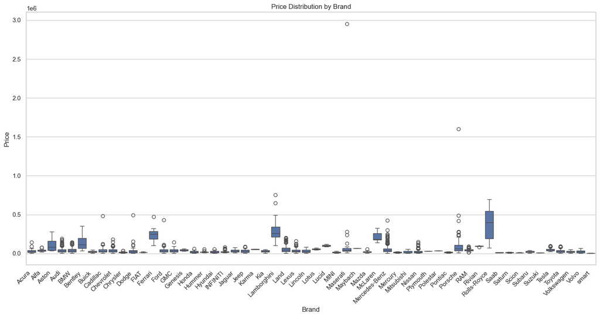

```python
import seaborn as sns
import matplotlib.pyplot as plt

# Convert price column to float after cleaning
df['price'] = df['price'].replace({'\$': '', ',': ''}, regex=True).astype(float)

plt.figure(figsize=(15, 8))  # Increase the figure size
sns.boxplot(data=df, x='brand', y='price')
plt.title('Price Distribution by Brand')
plt.xlabel('Brand')
plt.ylabel('Price')
plt.xticks(rotation=45, ha='right')  # Rotate x-axis labels
plt.tight_layout()  # Adjust the layout
plt.show()
```

2.Mileage Impact:

- Investigate how mileage impacts price.

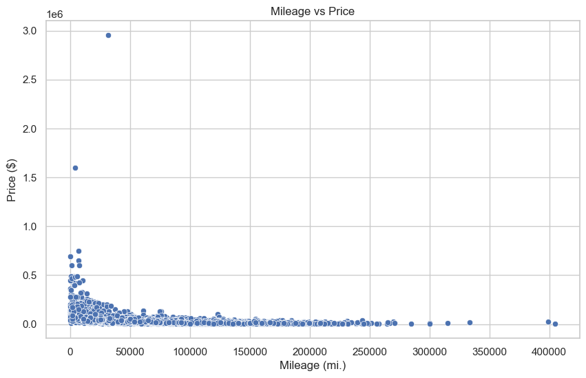

```python
plt.figure(figsize=(10, 6))
sns.scatterplot(x='milage', y='price', data=df)
plt.title('Mileage vs Price')
plt.xlabel('Mileage (mi.)')
plt.ylabel('Price ($)')
plt.show()
```

3.Segment Analysis:

- Use segmentation to identify potential customer groups based on price ranges, mileage, and other features.

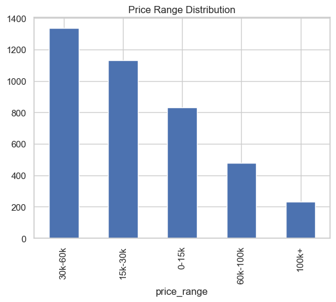

```python
# Example: segmenting by price range
bins = [0, 15000, 30000, 60000, 100000, float('inf')]
labels = ['0-15k', '15k-30k', '30k-60k', '60k-100k', '100k+']
df['price_range'] = pd.cut(df['price'], bins=bins, labels=labels)

price_segment_counts = df['price_range'].value_counts()
price_segment_counts.plot(kind='bar', title='Price Range Distribution')
plt.show()
```

4. Removing Outliers

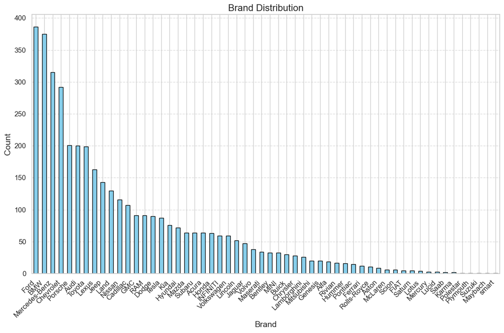

```python
import matplotlib.pyplot as plt

# Display the distribution of the 'brand' column
brand_distribution = df['brand'].value_counts()

# Plot the distribution with improved styling
plt.figure(figsize=(12, 8))  # Increase the figure size for better visibility
brand_distribution.plot(kind='bar', color='skyblue', edgecolor='black')

# Adding titles and labels
plt.title('Brand Distribution', fontsize=16)
plt.xlabel('Brand', fontsize=14)
plt.ylabel('Count', fontsize=14)

# Rotate x-axis labels for better readability
plt.xticks(rotation=45, ha='right', fontsize=12)

# Increase y-axis font size and add gridlines for better readability
plt.yticks(fontsize=12)
plt.grid(axis='y', linestyle='--', alpha=0.7)

# Show the plot
plt.tight_layout()  # Adjust layout to avoid overlap
plt.show()
```

```python
df_cleaned = df[df['price'] <= 200000]
```

```python
print(df_cleaned.shape)
```

```
(3934, 13)
```

```
count      3934.000000
mean      37884.626080
std       29948.902974
min        2000.000000
25%       17000.000000
50%       30500.000000
75%       48000.000000
max      200000.000000
Name: price, dtype: float64
```

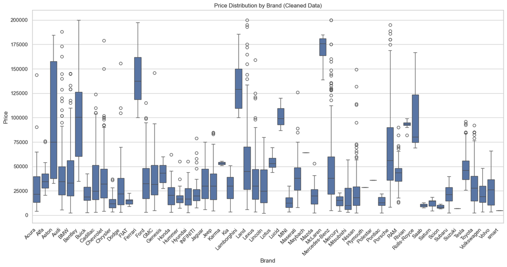

```python
# Check summary statistics
print(df_cleaned['price'].describe())

# Optionally, visualize again
plt.figure(figsize=(15, 8))
sns.boxplot(data=df_cleaned, x='brand', y='price')
plt.title('Price Distribution by Brand (Cleaned Data)')
plt.xlabel('Brand')
plt.ylabel('Price')
plt.xticks(rotation=45, ha='right')
plt.tight_layout()
plt.show()
```

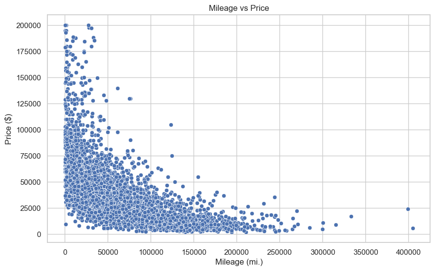

```python
plt.figure(figsize=(10, 6))
sns.scatterplot(x='milage', y='price', data=df_cleaned)
plt.title('Mileage vs Price')
plt.xlabel('Mileage (mi.)')
plt.ylabel('Price ($)')
plt.show()
```

## 1.Price Discrepancies by Brand:

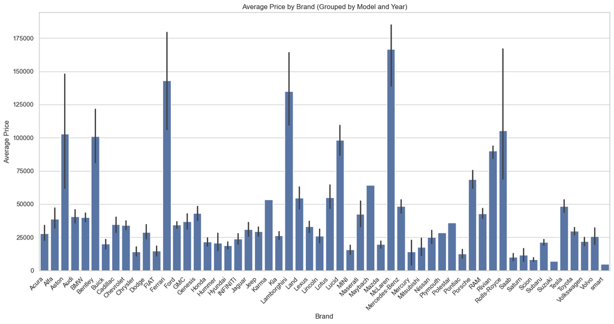

```python
import pandas as pd
import matplotlib.pyplot as plt
import seaborn as sns

# Step 1: Convert 'price' to float (if not done already in df_cleaned)
df_cleaned['price'] = df_cleaned['price'].replace({'\$': '', ',': ''}, regex=True).astype(float)

# Step 2: Group by 'brand', 'model', and 'model_year' and calculate the average price
brand_model_year_avg = df_cleaned.groupby(['brand', 'model', 'model_year'])['price'].mean().reset_index()

# Step 3: Sort values to easily identify discrepancies and trends
brand_model_year_avg = brand_model_year_avg.sort_values(by='price', ascending=False)

# Step 4: Display the top 10 entries for a quick view
brand_model_year_avg.head(10)

# Step 5: Visualization for better understanding
plt.figure(figsize=(15, 8))
sns.barplot(data=brand_model_year_avg, x='brand', y='price')
plt.title('Average Price by Brand (Grouped by Model and Year)')
plt.xlabel('Brand')
plt.ylabel('Average Price')
plt.xticks(rotation=45, ha='right')
plt.tight_layout()
plt.show()
```

```python
# Map the accident column to 'Yes' and 'No'
df_cleaned['accident'] = df_cleaned['accident'].replace({
    'At least 1 accident or damage reported': 'Yes',
    'None reported': 'No'
})
```

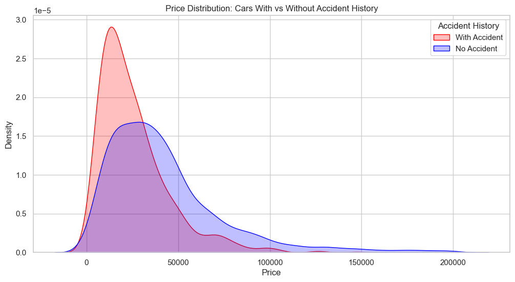

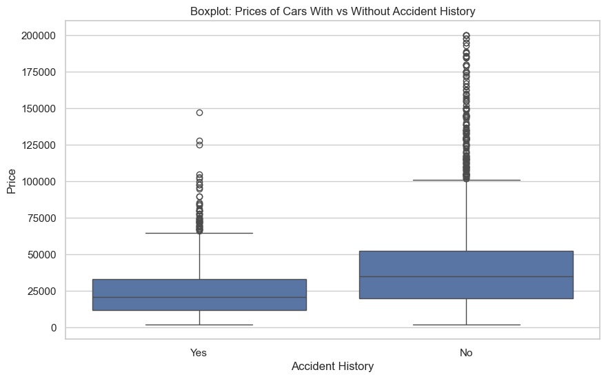

```python
import matplotlib.pyplot as plt
import seaborn as sns

# Step 1: Clean up the 'price' column if needed (remove '$' and commas, and convert to float)
df_cleaned['price'] = df_cleaned['price'].replace({'\$': '', ',': ''}, regex=True).astype(float)

# Step 2: Separate the data based on accident history
df_accident = df_cleaned[df_cleaned['accident'] == 'Yes']
df_no_accident = df_cleaned[df_cleaned['accident'] == 'No']

# Step 3: Visualize price distributions for cars with and without accidents
plt.figure(figsize=(12, 6))

# Plot for cars with accident history
sns.kdeplot(df_accident['price'], label='With Accident', shade=True, color='red')

# Plot for cars without accident history
sns.kdeplot(df_no_accident['price'], label='No Accident', shade=True, color='blue')

# Adding titles and labels
plt.title('Price Distribution: Cars With vs Without Accident History')
plt.xlabel('Price')
plt.ylabel('Density')
plt.legend(title="Accident History")  # Adding a title to the legend

# Display the plot
plt.show()

# Optional: Boxplot comparison for additional insight
plt.figure(figsize=(10, 6))
sns.boxplot(x='accident', y='price', data=df_cleaned)
plt.title('Boxplot: Prices of Cars With vs Without Accident History')
plt.xlabel('Accident History')
plt.ylabel('Price')
plt.show()
```

```python
df_cleaned.head()
```

|  | brand | model | model_year | milage | fuel_type | engine | transmission | ext_col | int_col | accident | clean_title | price | price_range |
| --- | --- | --- | --- | --- | --- | --- | --- | --- | --- | --- | --- | --- | --- |
| 0 | Ford | Utility Police Interceptor Base | 2013 | 51000 | E85 Flex Fuel | 300.0HP 3.7L V6 Cylinder Engine Flex Fuel Capa... | 6-Speed A/T | Black | Black | Yes | Yes | 10300.0 | 0-15k |
| 1 | Hyundai | Palisade SEL | 2021 | 34742 | Gasoline | 3.8L V6 24V GDI DOHC | 8-Speed Automatic | Moonlight Cloud | Gray | Yes | Yes | 38005.0 | 30k-60k |
| 2 | Lexus | RX 350 RX 350 | 2022 | 22372 | Gasoline | 3.5 Liter DOHC | Automatic | Blue | Black | No | No | 54598.0 | 30k-60k |
| 3 | INFINITI | Q50 Hybrid Sport | 2015 | 88900 | Hybrid | 354.0HP 3.5L V6 Cylinder Engine Gas/Electric H... | 7-Speed A/T | Black | Black | No | Yes | 15500.0 | 15k-30k |
| 4 | Audi | Q3 45 S line Premium Plus | 2021 | 9835 | Gasoline | 2.0L I4 16V GDI DOHC Turbo | 8-Speed Automatic | Glacier White Metallic | Black | No | No | 34999.0 | 30k-60k |

```python
# List of columns to apply one-hot encoding
one_hot_columns = ['brand', 'fuel_type', "transmission"]

# Apply one-hot encoding
df_encoded = pd.get_dummies(df_cleaned, columns=one_hot_columns, drop_first=False, dtype= int)

# Display the resulting DataFrame
df_encoded.head()
```

|  | model | model_year | milage | engine | ext_col | int_col | accident | clean_title | price | price_range | ... | transmission_F | transmission_M/T | transmission_Manual | transmission_Manual, 6-Spd | transmission_SCHEDULED FOR OR IN PRODUCTION | transmission_Single-Speed Fixed Gear | transmission_Transmission Overdrive Switch | transmission_Transmission w/Dual Shift Mode | transmission_Variable | transmission_– |
| --- | --- | --- | --- | --- | --- | --- | --- | --- | --- | --- | --- | --- | --- | --- | --- | --- | --- | --- | --- | --- | --- |
| 0 | Utility Police Interceptor Base | 2013 | 51000 | 300.0HP 3.7L V6 Cylinder Engine Flex Fuel Capa... | Black | Black | Yes | Yes | 10300.0 | 0-15k | ... | 0 | 0 | 0 | 0 | 0 | 0 | 0 | 0 | 0 | 0 |
| 1 | Palisade SEL | 2021 | 34742 | 3.8L V6 24V GDI DOHC | Moonlight Cloud | Gray | Yes | Yes | 38005.0 | 30k-60k | ... | 0 | 0 | 0 | 0 | 0 | 0 | 0 | 0 | 0 | 0 |
| 2 | RX 350 RX 350 | 2022 | 22372 | 3.5 Liter DOHC | Blue | Black | No | No | 54598.0 | 30k-60k | ... | 0 | 0 | 0 | 0 | 0 | 0 | 0 | 0 | 0 | 0 |
| 3 | Q50 Hybrid Sport | 2015 | 88900 | 354.0HP 3.5L V6 Cylinder Engine Gas/Electric H... | Black | Black | No | Yes | 15500.0 | 15k-30k | ... | 0 | 0 | 0 | 0 | 0 | 0 | 0 | 0 | 0 | 0 |
| 4 | Q3 45 S line Premium Plus | 2021 | 9835 | 2.0L I4 16V GDI DOHC Turbo | Glacier White Metallic | Black | No | No | 34999.0 | 30k-60k | ... | 0 | 0 | 0 | 0 | 0 | 0 | 0 | 0 | 0 | 0 |

5 rows × 136 columns

```python
from sklearn.preprocessing import LabelEncoder

# List of columns to apply label encoding
label_columns = ['brand', 'fuel_type', 'accident', 'clean_title']

# Create a dictionary to hold mappings for each column
column_mappings = {}

# Loop through each column and apply label encoding
for col in label_columns:
    label_encoder = LabelEncoder()  # Create a new LabelEncoder for each column
    df_cleaned[col] = label_encoder.fit_transform(df_cleaned[col])  # Apply label encoding

    # Store the mapping for the column
    column_mappings[col] = dict(zip(label_encoder.classes_, label_encoder.transform(label_encoder.classes_)))

# Now, you can access the mappings for each column
for col, mapping in column_mappings.items():
    print(f"Mapping for '{col}':")
    print(mapping)
    print("\n")
```

```
Mapping for 'brand':
{'Acura': 0, 'Alfa': 1, 'Aston': 2, 'Audi': 3, 'BMW': 4, 'Bentley': 5, 'Buick': 6, 'Cadillac': 7, 'Chevrolet': 8, 'Chrysler': 9, 'Dodge': 10, 'FIAT': 11, 'Ferrari': 12, 'Ford': 13, 'GMC': 14, 'Genesis': 15, 'Honda': 16, 'Hummer': 17, 'Hyundai': 18, 'INFINITI': 19, 'Jaguar': 20, 'Jeep': 21, 'Karma': …


Mapping for 'fuel_type':
{'Diesel': 0, 'E85 Flex Fuel': 1, 'Gasoline': 2, 'Hybrid': 3, 'Plug-In Hybrid': 4, 'Unknown': 5, 'not supported': 6, '–': 7}


Mapping for 'accident':
{'No': 0, 'Yes': 1}


Mapping for 'clean_title':
{'No': 0, 'Yes': 1}
```

## Customer Segmentation

```python
from sklearn.preprocessing import LabelEncoder

# List of columns to apply label encoding
label_columns = ['brand', 'fuel_type', 'transmission', 'ext_col', 'int_col', 'accident', 'clean_title']

# Create a LabelEncoder object
label_encoder = LabelEncoder()

# Apply label encoding to the specified columns
for col in label_columns:
    df_cleaned[col] = label_encoder.fit_transform(df_cleaned[col])

df_cleaned = df_cleaned.drop(columns=['model', 'engine', 'price_range'])
# Check the changes
df_cleaned.head()
```

|  | brand | model_year | milage | fuel_type | transmission | ext_col | int_col | accident | clean_title | price |
| --- | --- | --- | --- | --- | --- | --- | --- | --- | --- | --- |
| 0 | 13 | 2013 | 51000 | 1 | 16 | 23 | 12 | 1 | 1 | 10300.0 |
| 1 | 18 | 2021 | 34742 | 2 | 29 | 166 | 63 | 1 | 1 | 38005.0 |
| 2 | 26 | 2022 | 22372 | 2 | 37 | 32 | 12 | 0 | 0 | 54598.0 |
| 3 | 19 | 2015 | 88900 | 3 | 22 | 23 | 12 | 0 | 1 | 15500.0 |
| 4 | 3 | 2021 | 9835 | 2 | 29 | 106 | 12 | 0 | 0 | 34999.0 |

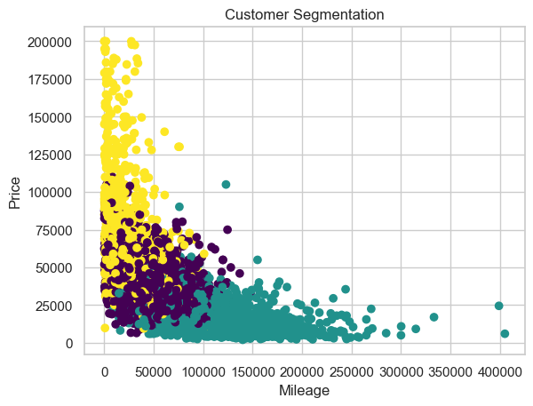

| cluster | brand | model_year | milage | fuel_type | transmission | ext_col | int_col | accident | clean_title | price |
| --- | --- | --- | --- | --- | --- | --- | --- | --- | --- | --- |
| 0 | 22.363805 | 2018.140828 | 45364.341569 | 2.020383 | 22.862878 | 141.431748 | 35.409512 | 0.216183 | 0.817789 | 38079.765287 |
| 1 | 22.276642 | 2009.275182 | 118050.672263 | 2.019708 | 29.487591 | 143.747445 | 33.097810 | 0.386131 | 0.963504 | 15494.959854 |
| 2 | 24.023280 | 2019.806349 | 25084.622222 | 2.602116 | 38.774603 | 137.960847 | 38.176720 | 0.111111 | 0.762963 | 70009.401058 |

```python
import pandas as pd
from sklearn.preprocessing import StandardScaler
from sklearn.cluster import KMeans
import matplotlib.pyplot as plt

# Assuming df_cleaned is your DataFrame

# Step 1: Select the features for clustering
features = df_cleaned[['model_year', 'milage', 'fuel_type', 'transmission', 'price']]

# Step 2: Convert categorical variables (e.g., fuel_type, transmission) into numeric values
# This can be done using one-hot encoding or label encoding
features = pd.get_dummies(features, drop_first=True)

# Step 3: Scale the features using StandardScaler (important for K-Means)
scaler = StandardScaler()
scaled_features = scaler.fit_transform(features)

# Step 4: Apply K-Means clustering (adjust the number of clusters as needed)
kmeans = KMeans(n_clusters=3, random_state=42)
df_cleaned['cluster'] = kmeans.fit_predict(scaled_features)

# Step 5: Analyze the resulting clusters
cluster_summary = df_cleaned.groupby('cluster').mean()

# Step 6: Visualize the clusters
plt.scatter(df_cleaned['milage'], df_cleaned['price'], c=df_cleaned['cluster'], cmap='viridis')
plt.xlabel('Mileage')
plt.ylabel('Price')
plt.title('Customer Segmentation')
plt.show()

# Print cluster summary
cluster_summary
```

## Price Sensitivity Analysis

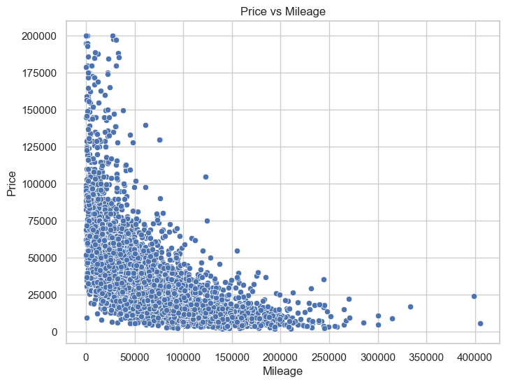

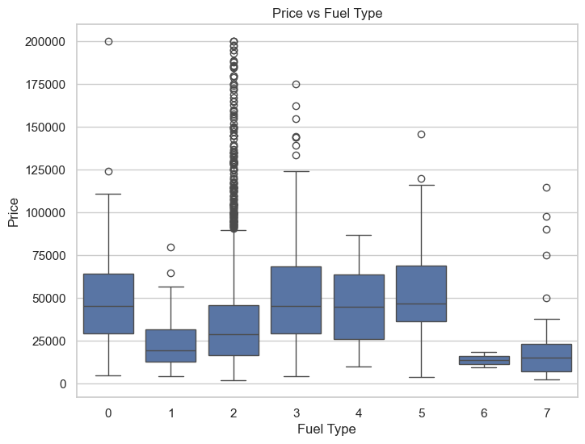

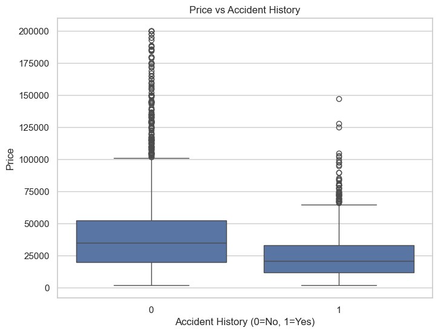

```python
import matplotlib.pyplot as plt
import seaborn as sns

# Scatter plot for mileage vs. price
plt.figure(figsize=(8, 6))
sns.scatterplot(x='milage', y='price', data=df_cleaned)
plt.title('Price vs Mileage')
plt.xlabel('Mileage')
plt.ylabel('Price')
plt.show()

# Box plot for price by fuel type
plt.figure(figsize=(8, 6))
sns.boxplot(x='fuel_type', y='price', data=df_cleaned)
plt.title('Price vs Fuel Type')
plt.xlabel('Fuel Type')
plt.ylabel('Price')
plt.show()

# Box plot for price by accident history
plt.figure(figsize=(8, 6))
sns.boxplot(x='accident', y='price', data=df_cleaned)
plt.title('Price vs Accident History')
plt.xlabel('Accident History (0=No, 1=Yes)')
plt.ylabel('Price')
plt.show()
```

- Mileage: The scatter plot will show if cars with lower mileage generally have higher prices.
- Fuel Type: The box plot will show if electric or hybrid cars tend to have higher prices compared to gasoline vehicles.
- Accident History: The box plot will reveal if cars with accidents tend to have lower prices compared to those with clean histories.

```python
# Correlation matrix for price with all relevant numerical features
correlation_matrix_all = df_cleaned[['milage', 'price', 'transmission', 'accident']].corr()
correlation_matrix_all
```

|  | milage | price | transmission | accident |
| --- | --- | --- | --- | --- |
| milage | 1.000000 | -0.577455 | -0.032348 | 0.294653 |
| price | -0.577455 | 1.000000 | 0.021816 | -0.235591 |
| transmission | -0.032348 | 0.021816 | 1.000000 | 0.024353 |
| accident | 0.294653 | -0.235591 | 0.024353 | 1.000000 |

```python
from sklearn.linear_model import LinearRegression
from sklearn.model_selection import train_test_split

# Define features (independent variables)
X = df_cleaned[['milage', 'fuel_type', 'accident']]
X = pd.get_dummies(X, drop_first=True)  # Convert categorical variables to numeric

# Define target (dependent variable)
y = df_cleaned['price']

# Split the data into training and testing sets
X_train, X_test, y_train, y_test = train_test_split(X, y, test_size=0.2, random_state=42)

# Train the linear regression model
model = LinearRegression()
model.fit(X_train, y_train)

# Predict and evaluate the model
y_pred = model.predict(X_test)

# Evaluate the model
print("Model coefficients:", model.coef_)
print("Model intercept:", model.intercept_)

# Calculate R-squared value
print("R-squared:", model.score(X_test, y_test))
```

```
Model coefficients: [-3.28011366e-01 -8.74295668e+02 -4.53414982e+03]
Model intercept: 62515.37019098582
R-squared: 0.34423802348614696
```

- The coefficients tell you how each feature influences the price.
- A higher mileage coefficient (likely negative) means that as mileage increases, the price tends to decrease.
- The fuel type and accident coefficients will show if these attributes affect the price, and by how much.

## Trend Analysis

```python
# Filter the dataset to remove rows where the model_year is before 1992
df_cleaned = df_cleaned[df_cleaned['model_year'] >= 1992]

# Check the changes
df_cleaned.head()
```

|  | brand | model_year | milage | fuel_type | transmission | ext_col | int_col | accident | clean_title | price | cluster |
| --- | --- | --- | --- | --- | --- | --- | --- | --- | --- | --- | --- |
| 0 | 13 | 2013 | 51000 | 1 | 16 | 23 | 12 | 1 | 1 | 10300.0 | 0 |
| 1 | 18 | 2021 | 34742 | 2 | 29 | 166 | 63 | 1 | 1 | 38005.0 | 0 |
| 2 | 26 | 2022 | 22372 | 2 | 37 | 32 | 12 | 0 | 0 | 54598.0 | 2 |
| 3 | 19 | 2015 | 88900 | 3 | 22 | 23 | 12 | 0 | 1 | 15500.0 | 1 |
| 4 | 3 | 2021 | 9835 | 2 | 29 | 106 | 12 | 0 | 0 | 34999.0 | 0 |

```python
import pandas as pd
import matplotlib.pyplot as plt
import seaborn as sns

# Ensure model_year is numeric
df_cleaned['model_year'] = pd.to_numeric(df_cleaned['model_year'], errors='coerce')

# Group data by model_year and calculate the average price
trend_data = df_cleaned.groupby('model_year')['price'].mean().reset_index()

# Check the resulting data
print(trend_data.head())
```

```
   model_year         price
0        1992  11500.000000
1        1993  22522.111111
2        1994   7539.857143
3        1995  25665.333333
4        1996  22437.375000
```

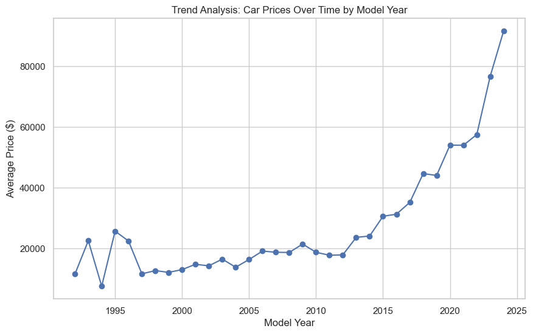

```python
# Set plot style
sns.set(style="whitegrid")

# Plotting
plt.figure(figsize=(10, 6))
plt.plot(trend_data['model_year'], trend_data['price'], marker='o', color='b')
plt.title('Trend Analysis: Car Prices Over Time by Model Year')
plt.xlabel('Model Year')
plt.ylabel('Average Price ($)')
plt.grid(True)
plt.show()
```

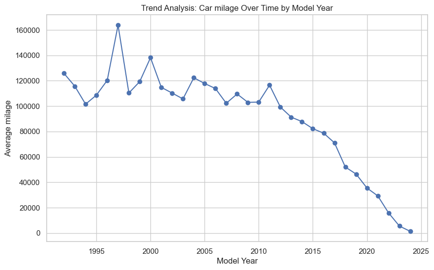

```python
mileage_trend = df_cleaned.groupby('model_year')['milage'].mean().reset_index()

# Set plot style
sns.set(style="whitegrid")

# Plotting
plt.figure(figsize=(10, 6))
plt.plot(mileage_trend['model_year'], mileage_trend['milage'], marker='o', color='b')
plt.title('Trend Analysis: Car milage Over Time by Model Year')
plt.xlabel('Model Year')
plt.ylabel('Average milage')
plt.grid(True)
plt.show()

# mileage_trend.head()
```

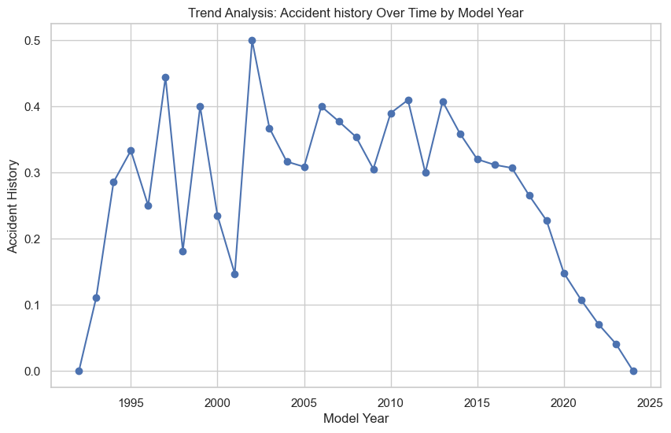

```python
accident_trend = df_cleaned.groupby('model_year')['accident'].mean().reset_index()

# Set plot style
sns.set(style="whitegrid")

# Plotting
plt.figure(figsize=(10, 6))
plt.plot(accident_trend['model_year'], accident_trend['accident'], marker='o', color='b')
plt.title('Trend Analysis: Accident history Over Time by Model Year')
plt.xlabel('Model Year')
plt.ylabel('Accident History')
plt.grid(True)
plt.show()
```

- Trend Analysis helps uncover patterns in the data, such as price depreciation over time or mileage accumulation by car age.
- The insights gained from trend analysis can be used for pricing strategies, inventory planning, and marketing decisions.

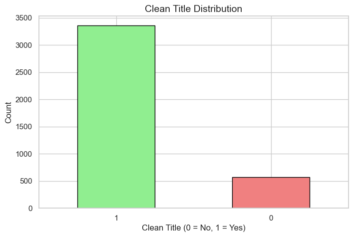

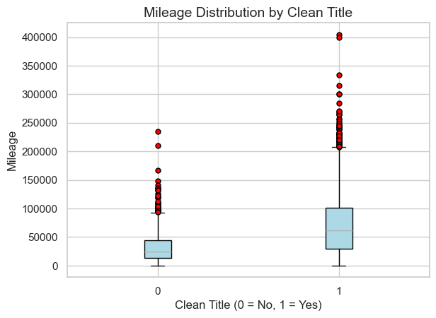

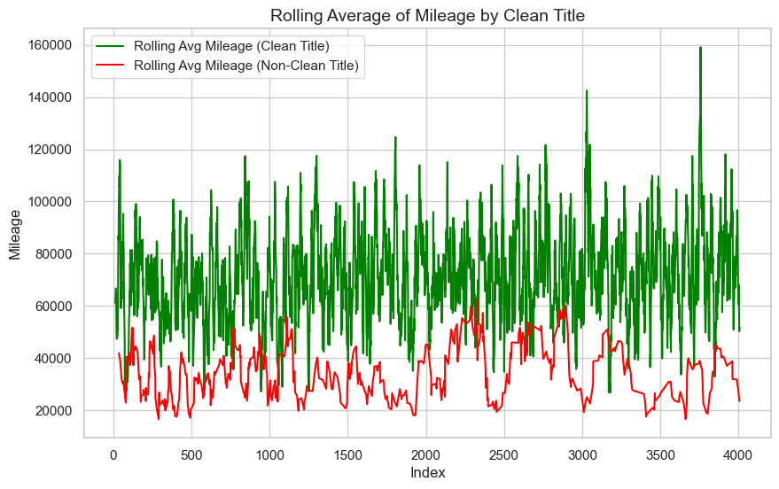

```python
import pandas as pd
import matplotlib.pyplot as plt

# Assuming df_cleaned is your DataFrame

# 1. Clean Title Distribution (Bar Plot)
clean_title_count = df_cleaned['clean_title'].value_counts()

plt.figure(figsize=(8, 5))
clean_title_count.plot(kind='bar', color=['lightgreen', 'lightcoral'], edgecolor='black')
plt.title('Clean Title Distribution', fontsize=14)
plt.xlabel('Clean Title (0 = No, 1 = Yes)', fontsize=12)
plt.ylabel('Count', fontsize=12)
plt.xticks(rotation=0)
plt.grid(True)
plt.show()

# 2. Mileage Distribution by Clean Title (Box Plot)
plt.figure(figsize=(10, 6))
df_cleaned.boxplot(column='milage', by='clean_title', patch_artist=True,
                  boxprops=dict(facecolor='lightblue', color='black'),
                  whiskerprops=dict(color='black'),
                  flierprops=dict(markerfacecolor='red', marker='o', markersize=5))
plt.title('Mileage Distribution by Clean Title', fontsize=14)
plt.suptitle('')
plt.xlabel('Clean Title (0 = No, 1 = Yes)', fontsize=12)
plt.ylabel('Mileage', fontsize=12)
plt.grid(True)
plt.show()

# 3. Rolling Average of Mileage for Clean Titles (Line Plot)
# Separate clean and non-clean titles
df_clean_title = df_cleaned[df_cleaned['clean_title'] == 1]
df_non_clean_title = df_cleaned[df_cleaned['clean_title'] == 0]

# Calculate the rolling average for both groups (window size 10)
df_clean_title['rolling_avg_mileage'] = df_clean_title['milage'].rolling(window=10).mean()
df_non_clean_title['rolling_avg_mileage'] = df_non_clean_title['milage'].rolling(window=10).mean()

plt.figure(figsize=(10, 6))
plt.plot(df_clean_title['rolling_avg_mileage'], label='Rolling Avg Mileage (Clean Title)', color='green')
plt.plot(df_non_clean_title['rolling_avg_mileage'], label='Rolling Avg Mileage (Non-Clean Title)', color='red')
plt.title('Rolling Average of Mileage by Clean Title', fontsize=14)
plt.xlabel('Index', fontsize=12)
plt.ylabel('Mileage', fontsize=12)
plt.legend()
plt.grid(True)
plt.show()
```

- Clean Title Distribution (Bar Plot): This will show a count of how many vehicles have a clean title (1 = Yes) and how many don't (0 = No).
- Mileage Distribution by Clean Title (Box Plot): This box plot will visualize how the mileage of vehicles with clean titles compares to those without. It shows the median, interquartile range, and outliers for each group.
- Rolling Average of Mileage for Clean Titles (Line Plot): This line plot shows the rolling average of mileage over a specified window of 10 for vehicles with and without clean titles, allowing you to see how mileage trends change over time within these two categories.
- The box plot will help compare how mileage is distributed based on clean title status.
- The rolling average plot will smooth out mileage data to detect trends and patterns based on clean title status.

```python
df_cleaned.head()
```

|  | brand | model_year | milage | fuel_type | transmission | ext_col | int_col | accident | clean_title | price | cluster |
| --- | --- | --- | --- | --- | --- | --- | --- | --- | --- | --- | --- |
| 0 | 13 | 2013 | 51000 | 1 | 16 | 23 | 12 | 1 | 1 | 10300.0 | 0 |
| 1 | 18 | 2021 | 34742 | 2 | 29 | 166 | 63 | 1 | 1 | 38005.0 | 0 |
| 2 | 26 | 2022 | 22372 | 2 | 37 | 32 | 12 | 0 | 0 | 54598.0 | 2 |
| 3 | 19 | 2015 | 88900 | 3 | 22 | 23 | 12 | 0 | 1 | 15500.0 | 1 |
| 4 | 3 | 2021 | 9835 | 2 | 29 | 106 | 12 | 0 | 0 | 34999.0 | 0 |

```python
# Selecting relevant features for recommendation
features = ['brand', 'model_year', 'milage', 'fuel_type', 'price']
df_features = df_cleaned[features]
```

```python
df_features.head()
```

|  | brand | model_year | milage | fuel_type | price |
| --- | --- | --- | --- | --- | --- |
| 0 | 13 | 2013 | 51000 | 1 | 10300.0 |
| 1 | 18 | 2021 | 34742 | 2 | 38005.0 |
| 2 | 26 | 2022 | 22372 | 2 | 54598.0 |
| 3 | 19 | 2015 | 88900 | 3 | 15500.0 |
| 4 | 3 | 2021 | 9835 | 2 | 34999.0 |

## Build a Recommendation System

```python
from sklearn.metrics.pairwise import cosine_similarity
import numpy as np

# Convert features to numeric values (if not already)
X = df_features.values

# Calculate cosine similarity
cosine_sim = cosine_similarity(X)

# Function to recommend vehicles
def recommend_vehicle(vehicle_index, cosine_sim=cosine_sim):
    # Get pairwise similarity scores for the given vehicle
    similarity_scores = list(enumerate(cosine_sim[vehicle_index]))

    # Sort the vehicles based on similarity scores
    similarity_scores = sorted(similarity_scores, key=lambda x: x[1], reverse=True)

    # Get the indices of the most similar vehicles
    similar_vehicles = [i[0] for i in similarity_scores[1:6]]  # top 5 recommendations

    return df.iloc[similar_vehicles]

# Example: Recommend vehicles similar to the vehicle at index 0
recommended_vehicles = recommend_vehicle(vehicle_index=0)
recommended_vehicles
```

|  | brand | model | model_year | milage | fuel_type | engine | transmission | ext_col | int_col | accident | clean_title | price | price_range |
| --- | --- | --- | --- | --- | --- | --- | --- | --- | --- | --- | --- | --- | --- |
| 2638 | Nissan | GT-R Premium | 2021 | 22185 | Gasoline | 3.8L V6 24V MPFI DOHC Twin Turbo | 6-Speed Automatic with Auto-Shift | Bayside Blue | Gray | None reported | Yes | 131999.0 | 100k+ |
| 299 | Porsche | 718 Cayman S | 2019 | 9500 | Gasoline | 350.0HP 2.5L 4 Cylinder Engine Gasoline Fuel | 7-Speed A/T | Red | Black | At least 1 accident or damage reported | Yes | 69000.0 | 60k-100k |
| 1111 | Mercedes-Benz | Metris Base | 2018 | 58350 | Gasoline | 208.0HP 2.0L 4 Cylinder Engine Gasoline Fuel | 7-Speed A/T | Black | Black | None reported | Yes | 29497.0 | 15k-30k |
| 3660 | Chevrolet | Impala Base | 2004 | 64500 | Gasoline | 180.0HP 3.4L V6 Cylinder Engine Gasoline Fuel | A/T | Beige | Beige | None reported | Yes | 5900.0 | 0-15k |
| 159 | Toyota | Tacoma PreRunner | 2008 | 202055 | Gasoline | 236.0HP 4.0L V6 Cylinder Engine Gasoline Fuel | A/T | Silver | Gray | At least 1 accident or damage reported | Yes | 8500.0 | 0-15k |

## Model: Price Prediction

```python
from sklearn.ensemble import RandomForestRegressor
from sklearn.model_selection import train_test_split
from sklearn.metrics import mean_absolute_error

# Prepare your data
X = df_cleaned[['milage', 'model_year', 'fuel_type', 'brand', 'accident']]  # Example features
y = df_cleaned['price']

# Split data into training and testing sets
X_train, X_test, y_train, y_test = train_test_split(X, y, test_size=0.2, random_state=42)

# Train the model
model = RandomForestRegressor(n_estimators=100, random_state=42)
model.fit(X_train, y_train)

# Make predictions
y_pred = model.predict(X_test)

# Evaluate the model
mae = mean_absolute_error(y_test, y_pred)
print(f'Mean Absolute Error: {mae}')
```

```
Mean Absolute Error: 12542.410142796638
```

## One Hot Encoding

```python
df_encoded.head()
```

|  | model | model_year | milage | engine | ext_col | int_col | accident | clean_title | price | price_range | ... | transmission_F | transmission_M/T | transmission_Manual | transmission_Manual, 6-Spd | transmission_SCHEDULED FOR OR IN PRODUCTION | transmission_Single-Speed Fixed Gear | transmission_Transmission Overdrive Switch | transmission_Transmission w/Dual Shift Mode | transmission_Variable | transmission_– |
| --- | --- | --- | --- | --- | --- | --- | --- | --- | --- | --- | --- | --- | --- | --- | --- | --- | --- | --- | --- | --- | --- |
| 0 | Utility Police Interceptor Base | 2013 | 51000 | 300.0HP 3.7L V6 Cylinder Engine Flex Fuel Capa... | Black | Black | Yes | Yes | 10300.0 | 0-15k | ... | 0 | 0 | 0 | 0 | 0 | 0 | 0 | 0 | 0 | 0 |
| 1 | Palisade SEL | 2021 | 34742 | 3.8L V6 24V GDI DOHC | Moonlight Cloud | Gray | Yes | Yes | 38005.0 | 30k-60k | ... | 0 | 0 | 0 | 0 | 0 | 0 | 0 | 0 | 0 | 0 |
| 2 | RX 350 RX 350 | 2022 | 22372 | 3.5 Liter DOHC | Blue | Black | No | No | 54598.0 | 30k-60k | ... | 0 | 0 | 0 | 0 | 0 | 0 | 0 | 0 | 0 | 0 |
| 3 | Q50 Hybrid Sport | 2015 | 88900 | 354.0HP 3.5L V6 Cylinder Engine Gas/Electric H... | Black | Black | No | Yes | 15500.0 | 15k-30k | ... | 0 | 0 | 0 | 0 | 0 | 0 | 0 | 0 | 0 | 0 |
| 4 | Q3 45 S line Premium Plus | 2021 | 9835 | 2.0L I4 16V GDI DOHC Turbo | Glacier White Metallic | Black | No | No | 34999.0 | 30k-60k | ... | 0 | 0 | 0 | 0 | 0 | 0 | 0 | 0 | 0 | 0 |

5 rows × 136 columns

```python
# Convert 'Yes' to 1 and 'No' to 0
df_encoded['accident'] = df_encoded['accident'].replace({'Yes': 1, 'No': 0})
df_encoded['clean_title'] = df_encoded['clean_title'].replace({'Yes':1, "No": 0})
df_encoded = df_encoded.drop(columns=["model", "engine", "ext_col", "int_col", "price_range"])
```

```python
df_encoded.head()
```

|  | model_year | milage | accident | clean_title | price | brand_Acura | brand_Alfa | brand_Aston | brand_Audi | brand_BMW | ... | transmission_F | transmission_M/T | transmission_Manual | transmission_Manual, 6-Spd | transmission_SCHEDULED FOR OR IN PRODUCTION | transmission_Single-Speed Fixed Gear | transmission_Transmission Overdrive Switch | transmission_Transmission w/Dual Shift Mode | transmission_Variable | transmission_– |
| --- | --- | --- | --- | --- | --- | --- | --- | --- | --- | --- | --- | --- | --- | --- | --- | --- | --- | --- | --- | --- | --- |
| 0 | 2013 | 51000 | 1 | 1 | 10300.0 | 0 | 0 | 0 | 0 | 0 | ... | 0 | 0 | 0 | 0 | 0 | 0 | 0 | 0 | 0 | 0 |
| 1 | 2021 | 34742 | 1 | 1 | 38005.0 | 0 | 0 | 0 | 0 | 0 | ... | 0 | 0 | 0 | 0 | 0 | 0 | 0 | 0 | 0 | 0 |
| 2 | 2022 | 22372 | 0 | 0 | 54598.0 | 0 | 0 | 0 | 0 | 0 | ... | 0 | 0 | 0 | 0 | 0 | 0 | 0 | 0 | 0 | 0 |
| 3 | 2015 | 88900 | 0 | 1 | 15500.0 | 0 | 0 | 0 | 0 | 0 | ... | 0 | 0 | 0 | 0 | 0 | 0 | 0 | 0 | 0 | 0 |
| 4 | 2021 | 9835 | 0 | 0 | 34999.0 | 0 | 0 | 0 | 1 | 0 | ... | 0 | 0 | 0 | 0 | 0 | 0 | 0 | 0 | 0 | 0 |

5 rows × 131 columns

```python
from sklearn.ensemble import RandomForestRegressor
from sklearn.model_selection import train_test_split
from sklearn.metrics import mean_absolute_error

# Prepare your data
X = df_encoded.drop(columns=["price"]) # Example features
y = df_encoded['price']

# Split data into training and testing sets
X_train, X_test, y_train, y_test = train_test_split(X, y, test_size=0.2, random_state=42)

# Train the model
model = RandomForestRegressor(n_estimators=100, random_state=42)
model.fit(X_train, y_train)

# Make predictions
y_pred = model.predict(X_test)

# Evaluate the model
mae = mean_absolute_error(y_test, y_pred)
print(f'Mean Absolute Error: {mae}')
```

```
Mean Absolute Error: 10608.713418254976
```